# examples_0601

When all replacement strings are **[palindromes](https://en.wikipedia.org/wiki/Palindrome)**, the resulting L-system pattern will have mirror symmetry, which helps create more compelling image. In nature, most animals (including humans) display [bilateral symmetry](https://en.wikipedia.org/wiki/Symmetry_in_biology#Bilateral_symmetry).

Consider the replacement rules below.

`A > ++C+BB+C+B`  
`B > A+AACAA+A`  
`C > A-AAC++CAA-A`

For each replacement rule, is the replacement palindromic?

- Does `A > ++C+BB+C+B` have a palindromic replacement?
- Does `B > A+AACAA+A` have a palindromic replacement?
- Does `C > A-AAC++CAA-A` have a palindromic replacement?

When all replacement strings are **[palindromes](https://en.wikipedia.org/wiki/Palindrome)**, the resulting L-system pattern will have mirror symmetry, which helps create more compelling image. In nature, most animals (including humans) display [bilateral symmetry](https://en.wikipedia.org/wiki/Symmetry_in_biology#Bilateral_symmetry).

Consider the replacement rules below.

`A > A-CBABBABB-A`  
`B > CCC--CCC`  
`C > A+B-+BB-B+A`

For each replacement rule, is the replacement palindromic?

- Does `A > A-CBABBABB-A` have a palindromic replacement?
- Does `B > CCC--CCC` have a palindromic replacement?
- Does `C > A+B-+BB-B+A` have a palindromic replacement?

When all replacement strings are **[palindromes](https://en.wikipedia.org/wiki/Palindrome)**, the resulting L-system pattern will have mirror symmetry, which helps create more compelling image. In nature, most animals (including humans) display [bilateral symmetry](https://en.wikipedia.org/wiki/Symmetry_in_biology#Bilateral_symmetry).

Consider the replacement rules below.

`A > C+B-AB+C`  
`B > BB+A++++B+BB`  
`C > BBC-ABA-CBB`

For each replacement rule, is the replacement palindromic?

- Does `A > C+B-AB+C` have a palindromic replacement?
- Does `B > BB+A++++B+BB` have a palindromic replacement?
- Does `C > BBC-ABA-CBB` have a palindromic replacement?

When all replacement strings are **[palindromes](https://en.wikipedia.org/wiki/Palindrome)**, the resulting L-system pattern will have mirror symmetry, which helps create more compelling image. In nature, most animals (including humans) display [bilateral symmetry](https://en.wikipedia.org/wiki/Symmetry_in_biology#Bilateral_symmetry).

Consider the replacement rules below.

`A > AC-A+BB+A-CA`  
`B > BA--A--AB`  
`C > -AB++A++BAA`

For each replacement rule, is the replacement palindromic?

- Does `A > AC-A+BB+A-CA` have a palindromic replacement?
- Does `B > BA--A--AB` have a palindromic replacement?
- Does `C > -AB++A++BAA` have a palindromic replacement?

When all replacement strings are **[palindromes](https://en.wikipedia.org/wiki/Palindrome)**, the resulting L-system pattern will have mirror symmetry, which helps create more compelling image. In nature, most animals (including humans) display [bilateral symmetry](https://en.wikipedia.org/wiki/Symmetry_in_biology#Bilateral_symmetry).

Consider the replacement rules below.

`A > CA+ABBBA+AC`  
`B > AA-BA--AB-AA`  
`C > CB+BCB++C`

For each replacement rule, is the replacement palindromic?

- Does `A > CA+ABBBA+AC` have a palindromic replacement?
- Does `B > AA-BA--AB-AA` have a palindromic replacement?
- Does `C > CB+BCB++C` have a palindromic replacement?

When all replacement strings are **[palindromes](https://en.wikipedia.org/wiki/Palindrome)**, the resulting L-system pattern will have mirror symmetry, which helps create more compelling image. In nature, most animals (including humans) display [bilateral symmetry](https://en.wikipedia.org/wiki/Symmetry_in_biology#Bilateral_symmetry).

Consider the replacement rules below.

`A > CCBCCBCC`  
`B > BCA+AAAA+AC-`  
`C > AA-CAAACCAA`

For each replacement rule, is the replacement palindromic?

- Does `A > CCBCCBCC` have a palindromic replacement?
- Does `B > BCA+AAAA+AC-` have a palindromic replacement?
- Does `C > AA-CAAACCAA` have a palindromic replacement?

When all replacement strings are **[palindromes](https://en.wikipedia.org/wiki/Palindrome)**, the resulting L-system pattern will have mirror symmetry, which helps create more compelling image. In nature, most animals (including humans) display [bilateral symmetry](https://en.wikipedia.org/wiki/Symmetry_in_biology#Bilateral_symmetry).

Consider the replacement rules below.

`A > C---ACA---C`  
`B > BA--------AB`  
`C > CA--C-+AC`

For each replacement rule, is the replacement palindromic?

- Does `A > C---ACA---C` have a palindromic replacement?
- Does `B > BA--------AB` have a palindromic replacement?
- Does `C > CA--C-+AC` have a palindromic replacement?

When all replacement strings are **[palindromes](https://en.wikipedia.org/wiki/Palindrome)**, the resulting L-system pattern will have mirror symmetry, which helps create more compelling image. In nature, most animals (including humans) display [bilateral symmetry](https://en.wikipedia.org/wiki/Symmetry_in_biology#Bilateral_symmetry).

Consider the replacement rules below.

`A > A+++B--BC++A`  
`B > B--C++C--B`  
`C > AABBBBCAA`

For each replacement rule, is the replacement palindromic?

- Does `A > A+++B--BC++A` have a palindromic replacement?
- Does `B > B--C++C--B` have a palindromic replacement?
- Does `C > AABBBBCAA` have a palindromic replacement?

When all replacement strings are **[palindromes](https://en.wikipedia.org/wiki/Palindrome)**, the resulting L-system pattern will have mirror symmetry, which helps create more compelling image. In nature, most animals (including humans) display [bilateral symmetry](https://en.wikipedia.org/wiki/Symmetry_in_biology#Bilateral_symmetry).

Consider the replacement rules below.

`A > B-CB+ACA+BC-B`  
`B > ACB----BCA`  
`C > B+CBBC+B`

For each replacement rule, is the replacement palindromic?

- Does `A > B-CB+ACA+BC-B` have a palindromic replacement?
- Does `B > ACB----BCA` have a palindromic replacement?
- Does `C > B+CBBC+B` have a palindromic replacement?

When all replacement strings are **[palindromes](https://en.wikipedia.org/wiki/Palindrome)**, the resulting L-system pattern will have mirror symmetry, which helps create more compelling image. In nature, most animals (including humans) display [bilateral symmetry](https://en.wikipedia.org/wiki/Symmetry_in_biology#Bilateral_symmetry).

Consider the replacement rules below.

`A > B-AABAA-B`  
`B > AC------CA`  
`C > ACA-B-A-B-ACA`

For each replacement rule, is the replacement palindromic?

- Does `A > B-AABAA-B` have a palindromic replacement?
- Does `B > AC------CA` have a palindromic replacement?
- Does `C > ACA-B-A-B-ACA` have a palindromic replacement?

Consider the [L system](https://en.wikipedia.org/wiki/L-system) defined by the following start and replacement rules:

- Start = FQ
- Rules:
  - F $\to$ JJJQ
  - J $\to$ JFQQ
  - Q $\to$ FQF

After 3 iterations, what string is developed? I'd recommend using [this tool](https://chadworley.github.io/Lsys_string_gen.html).

Consider the [L system](https://en.wikipedia.org/wiki/L-system) defined by the following start and replacement rules:

- Start = TTT
- Rules:
  - E $\to$ EMJ
  - J $\to$ TEMT
  - M $\to$ EE
  - T $\to$ EJT

After 3 iterations, what string is developed? I'd recommend using [this tool](https://chadworley.github.io/Lsys_string_gen.html).

Consider the [L system](https://en.wikipedia.org/wiki/L-system) defined by the following start and replacement rules:

- Start = AAR
- Rules:
  - A $\to$ RAA
  - B $\to$ ABAB
  - R $\to$ BRB

After 3 iterations, what string is developed? I'd recommend using [this tool](https://chadworley.github.io/Lsys_string_gen.html).

Consider the [L system](https://en.wikipedia.org/wiki/L-system) defined by the following start and replacement rules:

- Start = B
- Rules:
  - B $\to$ JMMJ
  - J $\to$ MJJ
  - M $\to$ JMBM

After 3 iterations, what string is developed? I'd recommend using [this tool](https://chadworley.github.io/Lsys_string_gen.html).

Consider the [L system](https://en.wikipedia.org/wiki/L-system) defined by the following start and replacement rules:

- Start = JAJ
- Rules:
  - A $\to$ JAAD
  - D $\to$ HHHA
  - H $\to$ JH
  - J $\to$ DD

After 3 iterations, what string is developed? I'd recommend using [this tool](https://chadworley.github.io/Lsys_string_gen.html).

Consider the [L system](https://en.wikipedia.org/wiki/L-system) defined by the following start and replacement rules:

- Start = DYX
- Rules:
  - D $\to$ DXYY
  - L $\to$ LLL
  - X $\to$ LY
  - Y $\to$ YYY

After 3 iterations, what string is developed? I'd recommend using [this tool](https://chadworley.github.io/Lsys_string_gen.html).

Consider the [L system](https://en.wikipedia.org/wiki/L-system) defined by the following start and replacement rules:

- Start = F
- Rules:
  - E $\to$ EFF
  - F $\to$ GEGG
  - G $\to$ EENG
  - N $\to$ GFF

After 3 iterations, what string is developed? I'd recommend using [this tool](https://chadworley.github.io/Lsys_string_gen.html).

Consider the [L system](https://en.wikipedia.org/wiki/L-system) defined by the following start and replacement rules:

- Start = Z
- Rules:
  - J $\to$ ZZJZ
  - T $\to$ JTZ
  - Z $\to$ TT

After 4 iterations, what string is developed? I'd recommend using [this tool](https://chadworley.github.io/Lsys_string_gen.html).

Consider the [L system](https://en.wikipedia.org/wiki/L-system) defined by the following start and replacement rules:

- Start = ZZ
- Rules:
  - C $\to$ CZ
  - F $\to$ ZCF
  - Z $\to$ ZF

After 4 iterations, what string is developed? I'd recommend using [this tool](https://chadworley.github.io/Lsys_string_gen.html).

Consider the [L system](https://en.wikipedia.org/wiki/L-system) defined by the following start and replacement rules:

- Start = H
- Rules:
  - E $\to$ JEEH
  - H $\to$ JHJ
  - J $\to$ EJ

After 4 iterations, what string is developed? I'd recommend using [this tool](https://chadworley.github.io/Lsys_string_gen.html).

Consider the $L$-system (and turn angle) defined below:

- Start: `A`
- Rules:  
  `A > [-CB][+CB][CB][--CB]`  
  `B > D+B-D-B+D`  
  `C > CC`  
  `D > B-D+A+D-B`
- Number of recursions (number of iterations):
  - 6
- Turn angle
  - 90°

Please use [this online tool](https://artockthedino.github.io/lsys.html) to generate the pattern using turtle graphics. Choose the matching pattern. (The initial angle should be $270$ degrees to match the orientation.)

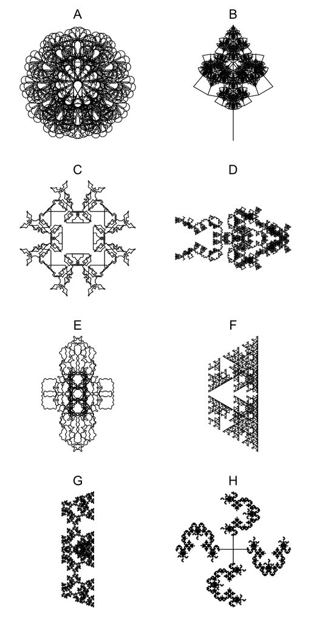

ABCDEFGH

The correct pattern is pattern H.

1. Use the first link: https://artockthedino.github.io/lsys.html
2. Copy/paste the `Axiom`, `Rules`, `Iterations`, and `Turn angle`.
3. Click `Generate Pattern`
4. Back to the quiz, select the matching pattern.

In case you're interested in the parameters of the other patterns shown:

## Pattern A

- Start: `A++++++.A`
- Rules:  
  `A > B+B+B+B+B+B+B`  
  `B > B[-CCA][+CCA]`  
  `C > CC`
- Number of recursions (number of iterations):
  - 5
- Angle
  - 30

## Pattern B

- Start: `A`
- Rules:  
  `A > CAA[--CAB][++CAB]`  
  `B > C[-CC-CA][+CC+CA]`  
  `C > CC`
- Number of recursions (number of iterations):
  - 5
- Angle
  - 100

## Pattern C

- Start: `AAAA`
- Rules:  
  `A > +BA+A-ABCBA-A+AB+`  
  `B > +BBA-B-CCCC-B-ABB+`  
  `C > CCCCC`
- Number of recursions (number of iterations):
  - 3
- Angle
  - 45

## Pattern D

- Start: `A`
- Rules:  
  `A > C--ABA--C`  
  `B > B+C+B`  
  `C > -CA+AC-`
- Number of recursions (number of iterations):
  - 6
- Angle
  - 120

## Pattern E

- Start: `AA`
- Rules:  
  `A > C--AA+B+AA--C`  
  `B > BA+C+AB`  
  `C > -B-CA++AC-B-`
- Number of recursions (number of iterations):
  - 4
- Angle
  - 30

## Pattern F

- Start: `A`
- Rules:  
  `A > +B-AAA-B+`  
  `B > -A+BBB+A-`
- Number of recursions (number of iterations):
  - 5
- Angle
  - 120

## Pattern G

- Start: `AA`
- Rules:  
  `A > +B-ABA-B+`  
  `B > -A+BAB+A-`
- Number of recursions (number of iterations):
  - 5
- Angle
  - 108

## Pattern H

- Start: `A`
- Rules:  
  `A > [-CB][+CB][CB][--CB]`  
  `B > D+B-D-B+D`  
  `C > CC`  
  `D > B-D+A+D-B`
- Number of recursions (number of iterations):
  - 6
- Angle
  - 90

Consider the $L$-system (and turn angle) defined below:

- Start: `CCC`
- Rules:  
  `A > C--ABA--C`  
  `B > B+C+B`  
  `C > -CA+AC-`
- Number of recursions (number of iterations):
  - 5
- Turn angle
  - 120°

Please use [this online tool](https://artockthedino.github.io/lsys.html) to generate the pattern using turtle graphics. Choose the matching pattern. (The initial angle should be $270$ degrees to match the orientation.)

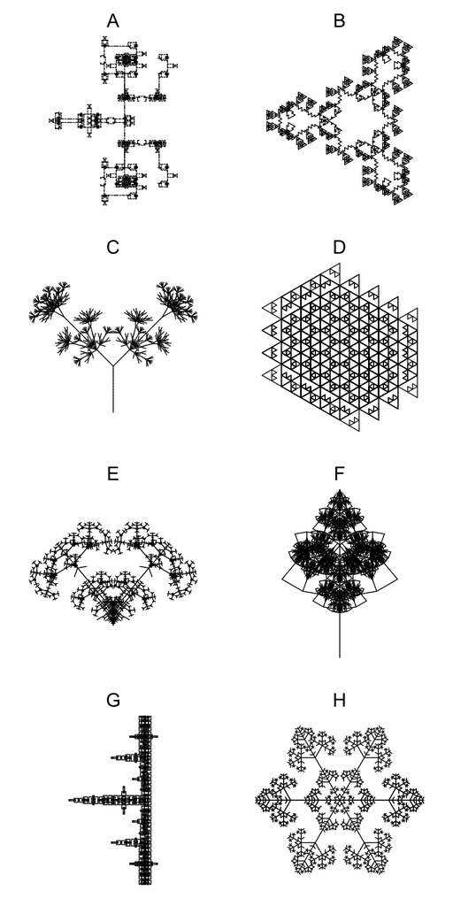

ABCDEFGH

The correct pattern is pattern B.

1. Use the first link: https://artockthedino.github.io/lsys.html
2. Copy/paste the `Axiom`, `Rules`, `Iterations`, and `Turn angle`.
3. Click `Generate Pattern`
4. Back to the quiz, select the matching pattern.

In case you're interested in the parameters of the other patterns shown:

## Pattern A

- Start: `A`
- Rules:  
  `A > +B++A-XCX-A++B+`  
  `B > -AX--BCB--XA-`  
  `C > C+AXBXA+C`  
  `X > XDX`  
  `D > DD`
- Number of recursions (number of iterations):
  - 5
- Angle
  - 90

## Pattern B

- Start: `CCC`
- Rules:  
  `A > C--ABA--C`  
  `B > B+C+B`  
  `C > -CA+AC-`
- Number of recursions (number of iterations):
  - 5
- Angle
  - 120

## Pattern C

- Start: `GA`
- Rules:  
  `A > [---BC][+++BC]`  
  `B > F[--AC][++AC]`  
  `C > FF[-BA][+BA]`  
  `F > FF`  
  `G > F`
- Number of recursions (number of iterations):
  - 5
- Angle
  - 15

## Pattern D

- Start: `A`
- Rules:  
  `A > +AA-B--A--B-AA+`  
  `B > -BB+A++B++A+BB-`
- Number of recursions (number of iterations):
  - 5
- Angle
  - 120

## Pattern E

- Start: `A`
- Rules:  
  `A > A[-DB][+DB]C`  
  `B > DC[++DA][--DA]B`  
  `C > [+++D][---D]A`  
  `D > DD`
- Number of recursions (number of iterations):
  - 6
- Angle
  - 40

## Pattern F

- Start: `A`
- Rules:  
  `A > CAA[--CAB][++CAB]`  
  `B > C[-CC-CA][+CC+CA]`  
  `C > CC`
- Number of recursions (number of iterations):
  - 5
- Angle
  - 100

## Pattern G

- Start: `A`
- Rules:  
  `A > B-ABA-B`  
  `B > A+B+A`
- Number of recursions (number of iterations):
  - 6
- Angle
  - 90

## Pattern H

- Start: `A------A`
- Rules:  
  `A > [---B][-B][+B][+++B]`  
  `B > BD[++DA][--DA]B`  
  `D > DD`
- Number of recursions (number of iterations):
  - 5
- Angle
  - 30

Consider the $L$-system (and turn angle) defined below:

- Start: `A`
- Rules:  
  `A > AXB+C+BXA`  
  `B > C--BAB--C`  
  `C > B+D-A-D+B`  
  `X > XX`  
  `D > DD`
- Number of recursions (number of iterations):
  - 5
- Turn angle
  - 108°

Please use [this online tool](https://artockthedino.github.io/lsys.html) to generate the pattern using turtle graphics. Choose the matching pattern. (The initial angle should be $270$ degrees to match the orientation.)

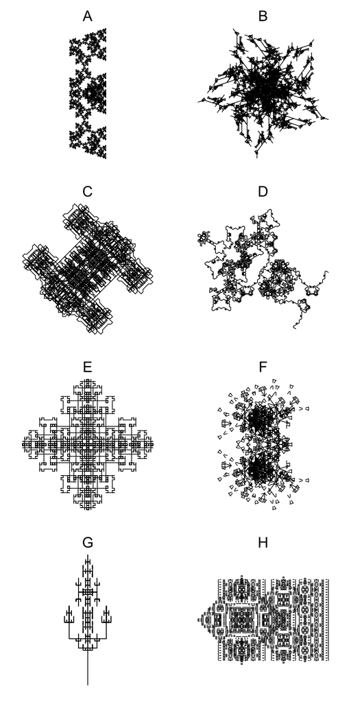

ABCDEFGH

The correct pattern is pattern F.

1. Use the first link: https://artockthedino.github.io/lsys.html
2. Copy/paste the `Axiom`, `Rules`, `Iterations`, and `Turn angle`.
3. Click `Generate Pattern`
4. Back to the quiz, select the matching pattern.

In case you're interested in the parameters of the other patterns shown:

## Pattern A

- Start: `AA`
- Rules:  
  `A > +B-ABA-B+`  
  `B > -A+BAB+A-`
- Number of recursions (number of iterations):
  - 5
- Angle
  - 108

## Pattern B

- Start: `AAAAA`
- Rules:  
  `A > A+B+A`  
  `B > CC-[+CA][-CA]-B`  
  `C > CC`
- Number of recursions (number of iterations):
  - 6
- Angle
  - 108

## Pattern C

- Start: `A--A`
- Rules:  
  `A > +B++ACA++B+`  
  `B > -A--BCB--A-`  
  `C > C+ABA+C`
- Number of recursions (number of iterations):
  - 5
- Angle
  - 45

## Pattern D

- Start: `A`
- Rules:  
  `A > C--A++B++A--C`  
  `B > BA+C+AB`  
  `C > -B-CA+AC-B-`
- Number of recursions (number of iterations):
  - 5
- Angle
  - 60

## Pattern E

- Start: `A-A-A-A`
- Rules:  
  `A > +B-A-B+`  
  `B > -A++B+C+B++A-`  
  `C > CC`
- Number of recursions (number of iterations):
  - 6
- Angle
  - 90

## Pattern F

- Start: `A`
- Rules:  
  `A > AXB+C+BXA`  
  `B > C--BAB--C`  
  `C > B+D-A-D+B`  
  `X > XX`  
  `D > DD`
- Number of recursions (number of iterations):
  - 5
- Angle
  - 108

## Pattern G

- Start: `A`
- Rules:  
  `A > CAA[--CAB][++CAB]`  
  `B > C[-CC-CA][+CC+CA]`  
  `C > CC`
- Number of recursions (number of iterations):
  - 5
- Angle
  - 90

## Pattern H

- Start: `A`
- Rules:  
  `A > +BX-AA-XB+`  
  `B > -AXB+B+BXA-`  
  `X > XX`
- Number of recursions (number of iterations):
  - 6
- Angle
  - 90

Consider the $L$-system (and turn angle) defined below:

- Start: `A`
- Rules:  
  `A > C--A++B++A--C`  
  `B > BA+C+AB`  
  `C > -B-CA+AC-B-`
- Number of recursions (number of iterations):
  - 5
- Turn angle
  - 60°

Please use [this online tool](https://artockthedino.github.io/lsys.html) to generate the pattern using turtle graphics. Choose the matching pattern. (The initial angle should be $270$ degrees to match the orientation.)

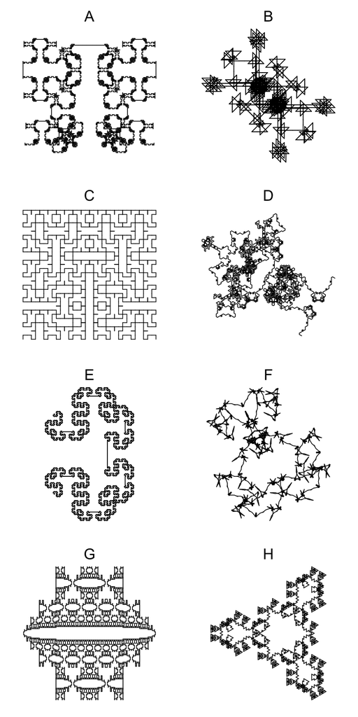

ABCDEFGH

The correct pattern is pattern D.

1. Use the first link: https://artockthedino.github.io/lsys.html
2. Copy/paste the `Axiom`, `Rules`, `Iterations`, and `Turn angle`.
3. Click `Generate Pattern`
4. Back to the quiz, select the matching pattern.

In case you're interested in the parameters of the other patterns shown:

## Pattern A

- Start: `A`
- Rules:  
  `A > +B-ACA-B+`  
  `B > -A++CB+BC++A-`  
  `C > CC`
- Number of recursions (number of iterations):
  - 6
- Angle
  - 90

## Pattern B

- Start: `A++A++A++A`
- Rules:  
  `A > B-CAC-B`  
  `B > AB-BA`  
  `C > CC`
- Number of recursions (number of iterations):
  - 5
- Angle
  - 135

## Pattern C

- Start: `-A`
- Rules:  
  `A > +B-AA-B+`  
  `B > -A+BB+A-`
- Number of recursions (number of iterations):
  - 5
- Angle
  - 90

## Pattern D

- Start: `A`
- Rules:  
  `A > C--A++B++A--C`  
  `B > BA+C+AB`  
  `C > -B-CA+AC-B-`
- Number of recursions (number of iterations):
  - 5
- Angle
  - 60

## Pattern E

- Start: `A`
- Rules:  
  `A > +BA-ACA-AB+`  
  `B > -AB+BCB+BA-`  
  `C > CCC`
- Number of recursions (number of iterations):
  - 5
- Angle
  - 90

## Pattern F

- Start: `A`
- Rules:  
  `A > C--ABA--C`  
  `B > BA+C+AB`  
  `C > -BCA+ACB-`
- Number of recursions (number of iterations):
  - 5
- Angle
  - 170

## Pattern G

- Start: `A++A`
- Rules:  
  `A > +B-CAC-B+`  
  `B > -A+BB+A-`  
  `C > CC`
- Number of recursions (number of iterations):
  - 6
- Angle
  - 90

## Pattern H

- Start: `CCC`
- Rules:  
  `A > C--ABA--C`  
  `B > B+C+B`  
  `C > -CA+AC-`
- Number of recursions (number of iterations):
  - 5
- Angle
  - 120

Consider the $L$-system (and turn angle) defined below:

- Start: `A`
- Rules:  
  `A > [---B][-B][+B][+++B]`  
  `B > BD[++DA][--DA]B`  
  `D > DD`
- Number of recursions (number of iterations):
  - 5
- Turn angle
  - 45°

Please use [this online tool](https://artockthedino.github.io/lsys.html) to generate the pattern using turtle graphics. Choose the matching pattern. (The initial angle should be $270$ degrees to match the orientation.)

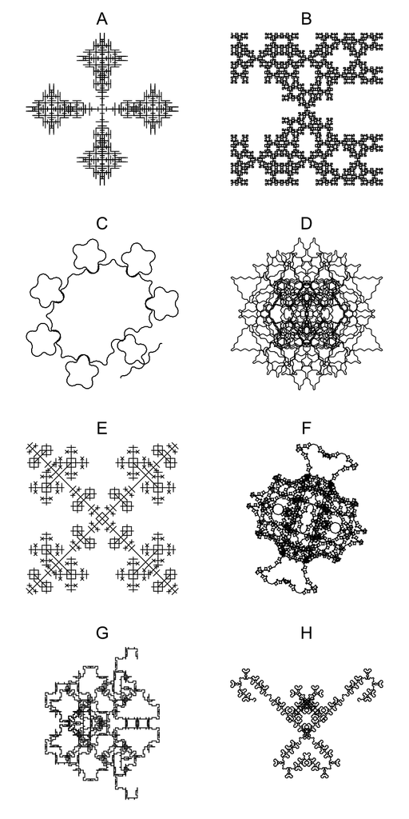

ABCDEFGH

The correct pattern is pattern E.

1. Use the first link: https://artockthedino.github.io/lsys.html
2. Copy/paste the `Axiom`, `Rules`, `Iterations`, and `Turn angle`.
3. Click `Generate Pattern`
4. Back to the quiz, select the matching pattern.

In case you're interested in the parameters of the other patterns shown:

## Pattern A

- Start: `[A]+[A]+[A]+[A]`
- Rules:  
  `A > AA[-B][+B]B`  
  `B > [-ABC][+ABC]`  
  `C > A[-CB][+CB]`
- Number of recursions (number of iterations):
  - 4
- Angle
  - 90

## Pattern B

- Start: `A`
- Rules:  
  `A > +BB-ABA-BB+`  
  `B > -AA+BAB+AA-`
- Number of recursions (number of iterations):
  - 5
- Angle
  - 90

## Pattern C

- Start: `A`
- Rules:  
  `A > +BAA-A-CC-A-AAB+`  
  `B > -C+++BAACAAB+++C-`  
  `C > CC`
- Number of recursions (number of iterations):
  - 4
- Angle
  - 10

## Pattern D

- Start: `AA`
- Rules:  
  `A > C--ABA+B+ABA--C`  
  `B > BA+C+AB`  
  `C > -B-CA++AC-B-`
- Number of recursions (number of iterations):
  - 4
- Angle
  - 30

## Pattern E

- Start: `A`
- Rules:  
  `A > [---B][-B][+B][+++B]`  
  `B > BD[++DA][--DA]B`  
  `D > DD`
- Number of recursions (number of iterations):
  - 5
- Angle
  - 45

## Pattern F

- Start: `A`
- Rules:  
  `A > +BA+ABCBA+AB+`  
  `B > -C+++BACAB+++C-`  
  `C > CC`
- Number of recursions (number of iterations):
  - 5
- Angle
  - 108

## Pattern G

- Start: `A`
- Rules:  
  `A > +BA+A-ABA-A+AB+`  
  `B > +BA-B--B-AB+`
- Number of recursions (number of iterations):
  - 4
- Angle
  - 90

## Pattern H

- Start: `AA`
- Rules:  
  `A > B-AA-B`  
  `B > A+B+A`
- Number of recursions (number of iterations):
  - 6
- Angle
  - 45

Consider the $L$-system (and turn angle) defined below:

- Start: `A`
- Rules:  
  `A > A[+A][-A]A[+B][-B]`  
  `B > A[--B][++B]B`
- Number of recursions (number of iterations):
  - 5
- Turn angle
  - 60°

Please use [this online tool](https://artockthedino.github.io/lsys.html) to generate the pattern using turtle graphics. Choose the matching pattern. (The initial angle should be $270$ degrees to match the orientation.)

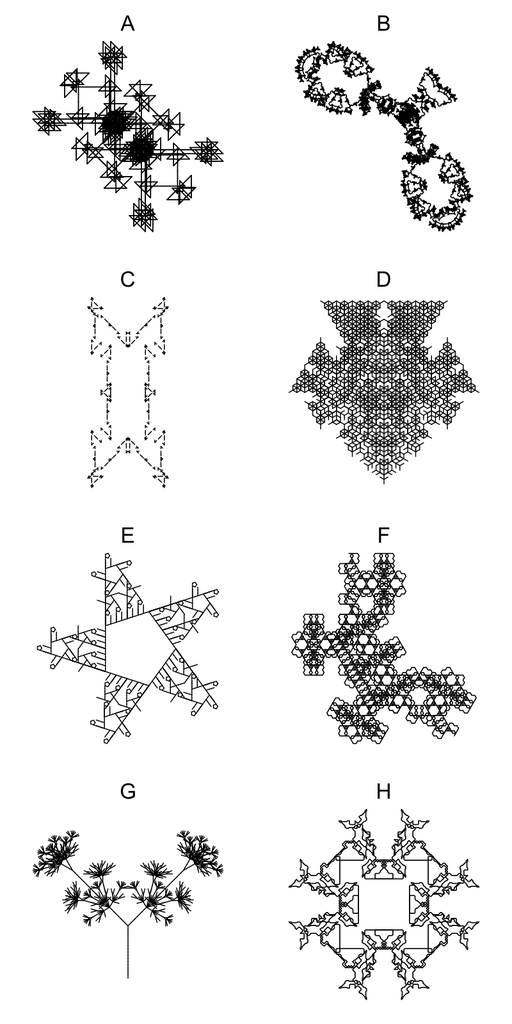

ABCDEFGH

The correct pattern is pattern D.

1. Use the first link: https://artockthedino.github.io/lsys.html
2. Copy/paste the `Axiom`, `Rules`, `Iterations`, and `Turn angle`.
3. Click `Generate Pattern`
4. Back to the quiz, select the matching pattern.

In case you're interested in the parameters of the other patterns shown:

## Pattern A

- Start: `A++A++A++A`
- Rules:  
  `A > B-CAC-B`  
  `B > AB-BA`  
  `C > CC`
- Number of recursions (number of iterations):
  - 5
- Angle
  - 135

## Pattern B

- Start: `BB`
- Rules:  
  `A > +BA+A-ABA-A+AB+`  
  `B > +BBA-B--B-ABB+`
- Number of recursions (number of iterations):
  - 4
- Angle
  - 69

## Pattern C

- Start: `A++++A`
- Rules:  
  `A > +B-AXBBXA-B+`  
  `B > -A+BXAAXB+A-`  
  `X > XX`
- Number of recursions (number of iterations):
  - 3
- Angle
  - 135

## Pattern D

- Start: `A`
- Rules:  
  `A > A[+A][-A]A[+B][-B]`  
  `B > A[--B][++B]B`
- Number of recursions (number of iterations):
  - 5
- Angle
  - 60

## Pattern E

- Start: `A`
- Rules:  
  `A > B+B+B+B+B`  
  `B > [-CCA]BB`  
  `C > CC`
- Number of recursions (number of iterations):
  - 5
- Angle
  - 72

## Pattern F

- Start: `A`
- Rules:  
  `A > +BA--AA--AB+`  
  `B > -AB++BB++BA-`
- Number of recursions (number of iterations):
  - 5
- Angle
  - 30

## Pattern G

- Start: `GA`
- Rules:  
  `A > [---BC][+++BC]`  
  `B > F[--AC][++AC]`  
  `C > FF[-BA][+BA]`  
  `F > FF`  
  `G > F`
- Number of recursions (number of iterations):
  - 5
- Angle
  - 15

## Pattern H

- Start: `AAAA`
- Rules:  
  `A > +BA+A-ABCBA-A+AB+`  
  `B > +BBA-B-CCCC-B-ABB+`  
  `C > CCCCC`
- Number of recursions (number of iterations):
  - 3
- Angle
  - 45

Consider the $L$-system (and turn angle) defined below:

- Start: `A`
- Rules:  
  `A > A--CBC--A`  
  `B > B+C+B`  
  `C > -CB+BC-`
- Number of recursions (number of iterations):
  - 6
- Turn angle
  - 90°

Please use [this online tool](https://artockthedino.github.io/lsys.html) to generate the pattern using turtle graphics. Choose the matching pattern. (The initial angle should be $270$ degrees to match the orientation.)

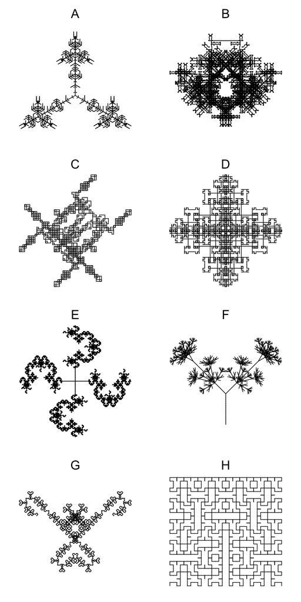

ABCDEFGH

The correct pattern is pattern C.

1. Use the first link: https://artockthedino.github.io/lsys.html
2. Copy/paste the `Axiom`, `Rules`, `Iterations`, and `Turn angle`.
3. Click `Generate Pattern`
4. Back to the quiz, select the matching pattern.

In case you're interested in the parameters of the other patterns shown:

## Pattern A

- Start: `[A]+[A]+[A]`
- Rules:  
  `A > AA[-B][+B]B`  
  `B > [-ABC][+ABC]`  
  `C > A[-CB][+CB]`
- Number of recursions (number of iterations):
  - 4
- Angle
  - 120

## Pattern B

- Start: `ABA`
- Rules:  
  `A > +B--A--B+`  
  `B > -A+BCB+A-`  
  `C > CC`
- Number of recursions (number of iterations):
  - 7
- Angle
  - 45

## Pattern C

- Start: `A`
- Rules:  
  `A > A--CBC--A`  
  `B > B+C+B`  
  `C > -CB+BC-`
- Number of recursions (number of iterations):
  - 6
- Angle
  - 90

## Pattern D

- Start: `A-A-A-A`
- Rules:  
  `A > +B-A-B+`  
  `B > -A++B+C+B++A-`  
  `C > CC`
- Number of recursions (number of iterations):
  - 6
- Angle
  - 90

## Pattern E

- Start: `A`
- Rules:  
  `A > [-CB][+CB][CB][--CB]`  
  `B > D+B-D-B+D`  
  `C > CC`  
  `D > B-D+A+D-B`
- Number of recursions (number of iterations):
  - 6
- Angle
  - 90

## Pattern F

- Start: `GA`
- Rules:  
  `A > [---BC][+++BC]`  
  `B > F[--AC][++AC]`  
  `C > FF[-BA][+BA]`  
  `F > FF`  
  `G > F`
- Number of recursions (number of iterations):
  - 5
- Angle
  - 15

## Pattern G

- Start: `AA`
- Rules:  
  `A > B-AA-B`  
  `B > A+B+A`
- Number of recursions (number of iterations):
  - 6
- Angle
  - 45

## Pattern H

- Start: `-A`
- Rules:  
  `A > +B-AA-B+`  
  `B > -A+BB+A-`
- Number of recursions (number of iterations):
  - 5
- Angle
  - 90

Consider the $L$-system (and turn angle) defined below:

- Start: `A`
- Rules:  
  `A > +BA+A-ABA-A+AB+`  
  `B > +BBA-B--B-ABB+`
- Number of recursions (number of iterations):
  - 3
- Turn angle
  - 45°

Please use [this online tool](https://artockthedino.github.io/lsys.html) to generate the pattern using turtle graphics. Choose the matching pattern. (The initial angle should be $270$ degrees to match the orientation.)

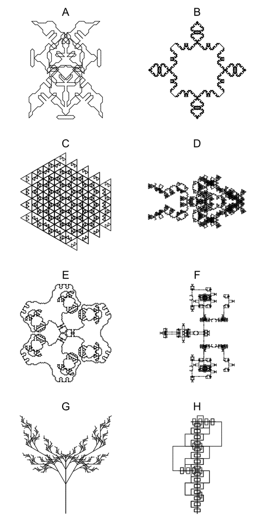

ABCDEFGH

The correct pattern is pattern A.

1. Use the first link: https://artockthedino.github.io/lsys.html
2. Copy/paste the `Axiom`, `Rules`, `Iterations`, and `Turn angle`.
3. Click `Generate Pattern`
4. Back to the quiz, select the matching pattern.

In case you're interested in the parameters of the other patterns shown:

## Pattern A

- Start: `A`
- Rules:  
  `A > +BA+A-ABA-A+AB+`  
  `B > +BBA-B--B-ABB+`
- Number of recursions (number of iterations):
  - 3
- Angle
  - 45

## Pattern B

- Start: `AAAA`
- Rules:  
  `A > +B++ACA++B+`  
  `B > -A--BCB--A-`  
  `C > CC`
- Number of recursions (number of iterations):
  - 5
- Angle
  - 45

## Pattern C

- Start: `A`
- Rules:  
  `A > +AA-B--A--B-AA+`  
  `B > -BB+A++B++A+BB-`
- Number of recursions (number of iterations):
  - 5
- Angle
  - 120

## Pattern D

- Start: `A`
- Rules:  
  `A > C--ABA--C`  
  `B > B+C+B`  
  `C > -CA+AC-`
- Number of recursions (number of iterations):
  - 6
- Angle
  - 120

## Pattern E

- Start: `AAA`
- Rules:  
  `A > C--AA++B++AA--C`  
  `B > BA+C+AB`  
  `C > -B-CA++AC-B-`
- Number of recursions (number of iterations):
  - 4
- Angle
  - 30

## Pattern F

- Start: `A`
- Rules:  
  `A > +B++A-XCX-A++B+`  
  `B > -AX--BCB--XA-`  
  `C > C+AXBXA+C`  
  `X > XDX`  
  `D > DD`
- Number of recursions (number of iterations):
  - 5
- Angle
  - 90

## Pattern G

- Start: `[A][B]`
- Rules:  
  `A > C[-A-B]A`  
  `B > C[+B+A]B`  
  `C > CC`
- Number of recursions (number of iterations):
  - 5
- Angle
  - 30

## Pattern H

- Start: `A`
- Rules:  
  `A > B++A++A++B`  
  `B > AB[A-CC-CC-CCA]BA`  
  `C > CC`
- Number of recursions (number of iterations):
  - 5
- Angle
  - 90

Consider the $L$-system (and turn angle) defined below:

- Start: `A------A`
- Rules:  
  `A > [---B][-B][+B][+++B]`  
  `B > BD[++DA][--DA]B`  
  `D > DD`
- Number of recursions (number of iterations):
  - 5
- Turn angle
  - 30°

Please use [this online tool](https://artockthedino.github.io/lsys.html) to generate the pattern using turtle graphics. Choose the matching pattern. (The initial angle should be $270$ degrees to match the orientation.)

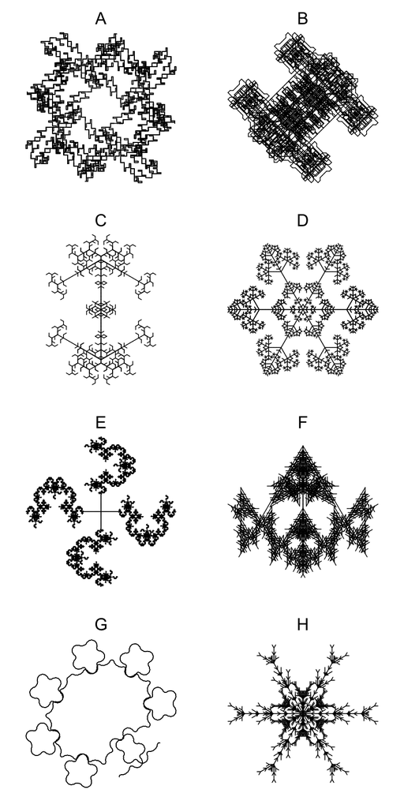

ABCDEFGH

The correct pattern is pattern D.

1. Use the first link: https://artockthedino.github.io/lsys.html
2. Copy/paste the `Axiom`, `Rules`, `Iterations`, and `Turn angle`.
3. Click `Generate Pattern`
4. Back to the quiz, select the matching pattern.

In case you're interested in the parameters of the other patterns shown:

## Pattern A

- Start: `A+A+A+A`
- Rules:  
  `A > C[++CB][--CB]`  
  `B > C-BAB+C`  
  `C > CAB`
- Number of recursions (number of iterations):
  - 6
- Angle
  - 90

## Pattern B

- Start: `A--A`
- Rules:  
  `A > +B++ACA++B+`  
  `B > -A--BCB--A-`  
  `C > C+ABA+C`
- Number of recursions (number of iterations):
  - 5
- Angle
  - 45

## Pattern C

- Start: `A+++A`
- Rules:  
  `A > BC`  
  `B > B[+C][-C]`  
  `C > CAD`  
  `D > DD[+D+D][-D-D]`
- Number of recursions (number of iterations):
  - 5
- Angle
  - 60

## Pattern D

- Start: `A------A`
- Rules:  
  `A > [---B][-B][+B][+++B]`  
  `B > BD[++DA][--DA]B`  
  `D > DD`
- Number of recursions (number of iterations):
  - 5
- Angle
  - 30

## Pattern E

- Start: `A`
- Rules:  
  `A > [-CB][+CB][CB][--CB]`  
  `B > D+B-D-B+D`  
  `C > CC`  
  `D > B-D+A+D-B`
- Number of recursions (number of iterations):
  - 6
- Angle
  - 90

## Pattern F

- Start: `[+A][-B]`
- Rules:  
  `A > [-CA-CB]A`  
  `B > [+CB+CA]B`  
  `C > CC`
- Number of recursions (number of iterations):
  - 6
- Angle
  - 150

## Pattern G

- Start: `A`
- Rules:  
  `A > +BAA-A-CC-A-AAB+`  
  `B > -C+++BAACAAB+++C-`  
  `C > CC`
- Number of recursions (number of iterations):
  - 4
- Angle
  - 10

## Pattern H

- Start: `A++++A++++A`
- Rules:  
  `A > [+BCC][-BCC]`  
  `B > B[-CA][+CA]`  
  `C > CCA`
- Number of recursions (number of iterations):
  - 5
- Angle
  - 30

Consider the $L$-system (and turn angle) defined below:

- Start: `AAAA`
- Rules:  
  `A > +BA+A-ABCBA-A+AB+`  
  `B > +BBA-B-CCCC-B-ABB+`  
  `C > CCCCC`
- Number of recursions (number of iterations):
  - 3
- Turn angle
  - 45°

Please use [this online tool](https://artockthedino.github.io/lsys.html) to generate the pattern using turtle graphics. Choose the matching pattern. (The initial angle should be $270$ degrees to match the orientation.)

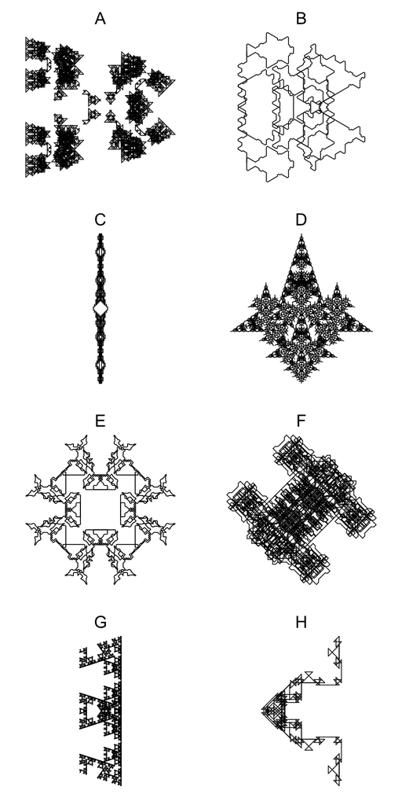

ABCDEFGH

The correct pattern is pattern E.

1. Use the first link: https://artockthedino.github.io/lsys.html
2. Copy/paste the `Axiom`, `Rules`, `Iterations`, and `Turn angle`.
3. Click `Generate Pattern`
4. Back to the quiz, select the matching pattern.

In case you're interested in the parameters of the other patterns shown:

## Pattern A

- Start: `B`
- Rules:  
  `A > +B-AXA-B+`  
  `B > -BA+BAB+AB-`  
  `X > XX`
- Number of recursions (number of iterations):
  - 5
- Angle
  - 135

## Pattern B

- Start: `A`
- Rules:  
  `A > ADB+D+BDA`  
  `B > C-DAD-C`  
  `C > B+A-D-A+B`  
  `D > DD`
- Number of recursions (number of iterations):
  - 5
- Angle
  - 60

## Pattern C

- Start: `A--A`
- Rules:  
  `A > +B-CAC-B+`  
  `B > -A+B+A-`  
  `C > CC`
- Number of recursions (number of iterations):
  - 6
- Angle
  - 90

## Pattern D

- Start: `A`
- Rules:  
  `A > A[+A][-A]B`  
  `B > A[--B][++B]B`
- Number of recursions (number of iterations):
  - 6
- Angle
  - 108

## Pattern E

- Start: `AAAA`
- Rules:  
  `A > +BA+A-ABCBA-A+AB+`  
  `B > +BBA-B-CCCC-B-ABB+`  
  `C > CCCCC`
- Number of recursions (number of iterations):
  - 3
- Angle
  - 45

## Pattern F

- Start: `A--A`
- Rules:  
  `A > +B++ACA++B+`  
  `B > -A--BCB--A-`  
  `C > C+ABA+C`
- Number of recursions (number of iterations):
  - 5
- Angle
  - 45

## Pattern G

- Start: `AA`
- Rules:  
  `A > +B-AAA-B+`  
  `B > -A+BBB+A-`
- Number of recursions (number of iterations):
  - 5
- Angle
  - 108

## Pattern H

- Start: `A`
- Rules:  
  `A > B-ABA-B`  
  `B > A+B+A`
- Number of recursions (number of iterations):
  - 4
- Angle
  - 135